# ASHIKABHAT-ML-GRADED-ASSIGNMENT

```python
import pandas as pd
import numpy as np
%matplotlib inline
import math
import matplotlib as mpl
import matplotlib.pyplot as plt
import seaborn as sb
from scipy import stats
import seaborn as sns
import scipy as sp
import scipy.stats as sps
from sklearn.linear_model import LinearRegression
from sklearn.tree import DecisionTreeRegressor
from sklearn.metrics import r2_score
from sklearn.metrics import mean_squared_error
from sklearn.preprocessing import PolynomialFeatures
from sklearn.linear_model import Ridge
from sklearn.model_selection import cross_val_predict
from sklearn.model_selection import cross_val_score
from sklearn.model_selection import GridSearchCV
```

```python
from sklearn.linear_model import LinearRegression
from sklearn.tree import DecisionTreeRegressor
from sklearn.ensemble import RandomForestRegressor, GradientBoostingRegressor
from sklearn.svm import SVR
from sklearn.neural_network import MLPRegressor
from sklearn.metrics import mean_squared_error, mean_absolute_error, r2_score
```

```python
# Load dataset
df = pd.read_csv('Life expectancy.csv')
```

```python
# Display the first few rows of the dataset
df.head()
```

|  | Country | Status | Adult_Mortality | Infant_Deaths | Hepatitis | Measles | BMI | Underfive_Deaths | Polio | Diphtheria | HIV | GDP | Population | Malnourished10_19 | Malnourished5_9 | Income_Index | Schooling | Expected |
| --- | --- | --- | --- | --- | --- | --- | --- | --- | --- | --- | --- | --- | --- | --- | --- | --- | --- | --- |
| 0 | Afghanistan | Developing | 263 | 62.0 | 65.0 | 1154 | 19.1 | NaN | 6 | 65 | 0.1 | 584.259210 | 33736494 | 17.2 | 17.3 | 0.479 | NaN | 65.0 |
| 1 | Albania | Developing | 8 | 0.0 | 98.0 | 0 | 57.2 | NaN | 98 | 98 | 0.1 | 4575.763787 | 288914 | 1.2 | 1.3 | 0.761 | 14.2 | 77.5 |
| 2 | Algeria | Developing | 19 | 21.0 | 95.0 | 63 | 59.5 | NaN | 95 | 95 | 0.1 | 4132.762920 | 39871528 | 6.0 | 5.8 | 0.743 | 14.4 | 75.6 |
| 3 | Angola | Developing | 335 | 66.0 | 64.0 | 118 | 23.3 | NaN | 7 | 64 | 1.9 | 3695.793748 | 2785935 | 8.3 | 8.2 | 0.531 | 11.4 | 52.4 |
| 4 | Argentina | Developing | 116 | 8.0 | 94.0 | 0 | 62.8 | NaN | 93 | 94 | 0.1 | 13467.123600 | 43417765 | 1.0 | 0.9 | 0.826 | 17.3 | 76.3 |

```python
# Summary statistics
df.describe()
```

|  | Adult_Mortality | Infant_Deaths | Hepatitis | Measles | BMI | Underfive_Deaths | Polio | Diphtheria | HIV | GDP | Population | Malnourished10_19 | Malnourished5_9 | Income_Index | Schooling | Expected |
| --- | --- | --- | --- | --- | --- | --- | --- | --- | --- | --- | --- | --- | --- | --- | --- | --- |
| count | 124.000000 | 110.000000 | 119.000000 | 124.000000 | 124.000000 | 119.000000 | 124.000000 | 124.000000 | 124.000000 | 124.000000 | 1.240000e+02 | 124.000000 | 124.000000 | 121.000000 | 119.000000 | 124.000000 |
| mean | 160.475806 | 28.545455 | 87.596639 | 2841.637097 | 41.733871 | 43.957983 | 86.637097 | 87.919355 | 0.819355 | 6866.816502 | 1.960604e+07 | 4.180645 | 4.373387 | 15.874140 | 14.670588 | 71.220968 |
| std | 101.794506 | 100.156267 | 24.578590 | 11517.586950 | 21.186385 | 158.755563 | 21.653342 | 19.122879 | 1.764127 | 10885.243579 | 4.100762e+07 | 4.086736 | 4.212797 | 117.829559 | 11.668953 | 8.467924 |
| min | 3.000000 | 0.000000 | 6.000000 | 0.000000 | 2.100000 | 0.000000 | 6.000000 | 6.000000 | 0.100000 | 5.668726 | 8.381000e+03 | 0.300000 | 0.200000 | 0.000000 | 0.000000 | 48.600000 |
| 25% | 73.500000 | 0.000000 | 85.000000 | 0.750000 | 20.950000 | 1.000000 | 88.000000 | 89.000000 | 0.100000 | 639.799727 | 8.215560e+05 | 1.500000 | 1.575000 | 0.511000 | 11.400000 | 65.175000 |
| 50% | 139.500000 | 4.000000 | 94.000000 | 37.000000 | 54.100000 | 7.000000 | 95.000000 | 95.000000 | 0.100000 | 2728.291765 | 4.234054e+06 | 2.400000 | 2.800000 | 0.734000 | 13.600000 | 72.200000 |
| 75% | 234.000000 | 19.750000 | 97.500000 | 588.750000 | 59.750000 | 23.500000 | 98.000000 | 98.000000 | 0.400000 | 8437.562893 | 1.482767e+07 | 6.425000 | 6.425000 | 0.799000 | 15.200000 | 77.500000 |
| max | 438.000000 | 910.000000 | 198.000000 | 90387.000000 | 71.400000 | 1110.000000 | 99.000000 | 99.000000 | 8.100000 | 56554.387600 | 2.581621e+08 | 26.700000 | 27.300000 | 923.000000 | 101.000000 | 86.000000 |

```python
#remove non numeric column 'Country'
df= df.drop(['Country'], axis=1)
```

```python
#encode the 'Status' column: 0 for Developing, 1 for Developed
df['Status'] = df['Status'].apply(lambda x:1 if x == 'Developed' else 0)
```

```python
# Check for missing values
print(df.isnull().sum())
```

```
Status                 0
Adult_Mortality        0
Infant_Deaths         14
Hepatitis              5
Measles                0
 BMI                   0
Underfive_Deaths       5
Polio                  0
Diphtheria             0
 HIV                   0
GDP                    0
Population             0
Malnourished10_19      0
Malnourished5_9        0
Income_Index           3
Schooling              5
Expected               0
dtype: int64
```

```python
# Handle missing values using SimpleImputer
imputer = SimpleImputer(strategy='mean')
df[df.columns] = imputer.fit_transform(df)
```

```python
# Verify there are no missing values left
print(df.isnull().sum())
```

```
Status                0
Adult_Mortality       0
Infant_Deaths         0
Hepatitis             0
Measles               0
 BMI                  0
Underfive_Deaths      0
Polio                 0
Diphtheria            0
 HIV                  0
GDP                   0
Population            0
Malnourished10_19     0
Malnourished5_9       0
Income_Index          0
Schooling             0
Expected              0
dtype: int64
```

```python
##Step 2: Feature Engineering
# Encode categorical variables
df = pd.get_dummies(df, columns=['Status'], drop_first=True)
```

```python
# Separate features and target variable
X = df.drop(['Expected'], axis=1)
y = df['Expected']
```

```python
# Split data into training and testing sets
X_train, X_test, y_train, y_test = train_test_split(X, y, test_size=0.2, random_state=42)
```

```
array([[<Axes: title={'center': 'Adult_Mortality'}>,
        <Axes: title={'center': 'Infant_Deaths'}>,
        <Axes: title={'center': 'Hepatitis '}>,
        <Axes: title={'center': 'Measles '}>],
       [<Axes: title={'center': ' BMI '}>,
        <Axes: title={'center': 'Underfive_Deaths '}>,
        <Axes: title={'center': 'Polio'}>,
        <Axes: title={'center': 'Diphtheria '}>],
       [<Axes: title={'center': ' HIV'}>,
        <Axes: title={'center': 'GDP'}>,
        <Axes: title={'center': 'Population'}>,
        <Axes: title={'center': 'Malnourished10_19 '}>],
       [<Axes: title={'center': 'Malnourished5_9'}>,
        <Axes: title={'center': 'Income_Index'}>,
        <Axes: title={'center': 'Schooling'}>,
        <Axes: title={'center': 'Expected'}>],
       [<Axes: title={'center': 'Status_1.0'}>, <Axes: >, <Axes: >,
        <Axes: >]], dtype=object)
```

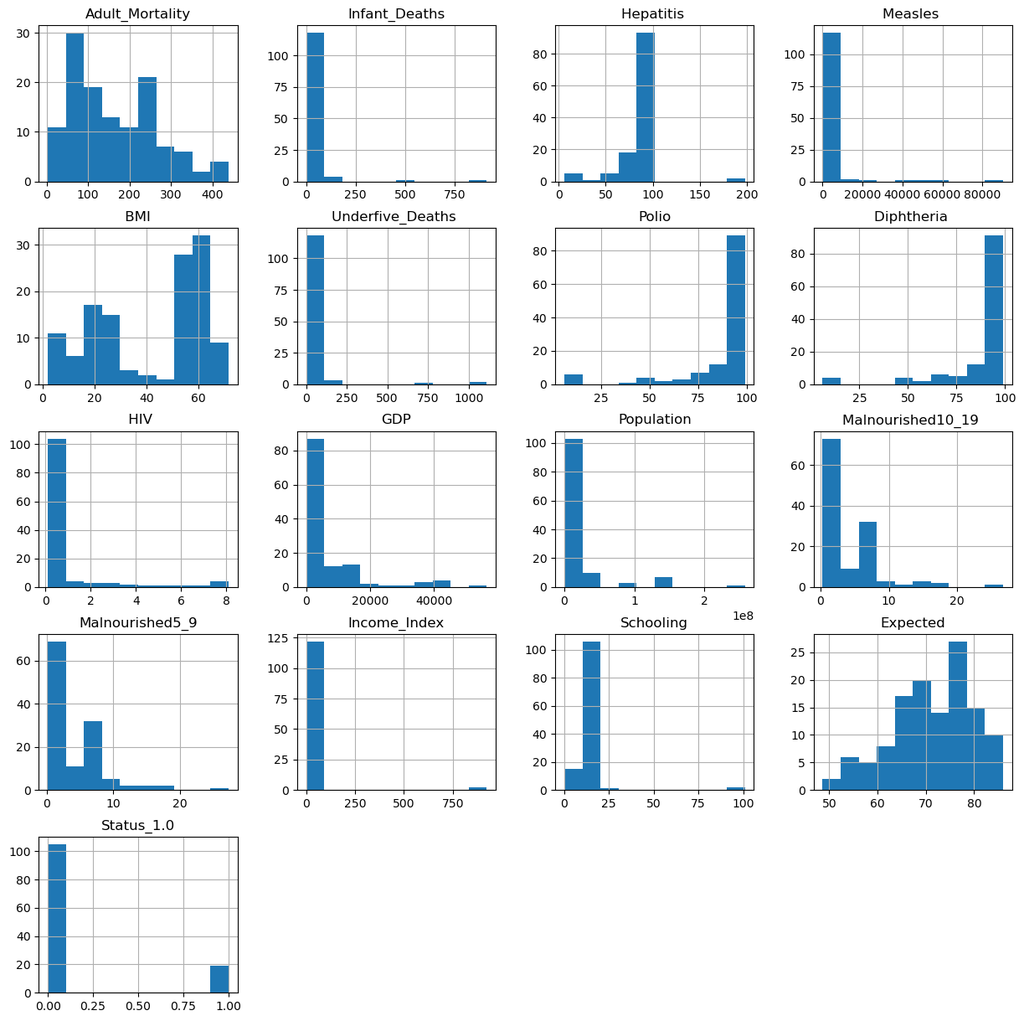

```python
# Step 3: Data Visualization
# Distribution of Life Expectancy
df.hist(figsize=(15,15))
```

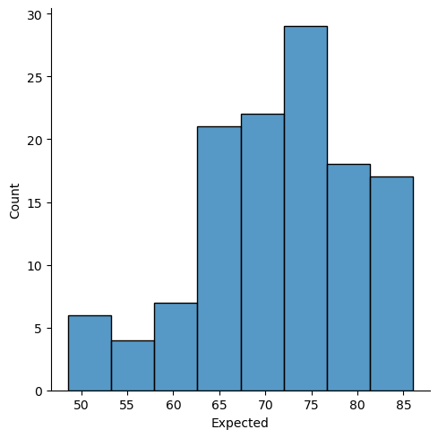

```python
plt.figure(figsize=(12,5))
sns.displot(df['Expected'])
plt.show()
```

```python
##Life expectancy is slightly left-skewed.
```

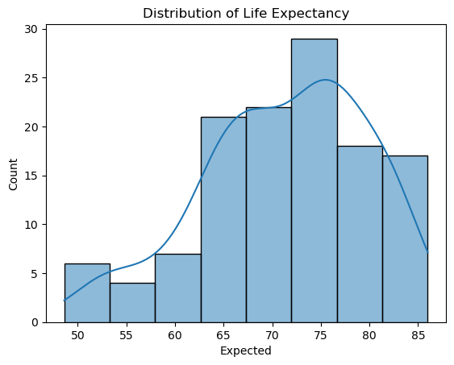

```python
sns.histplot(df['Expected'], kde=True)
plt.title('Distribution of Life Expectancy')
plt.show()
```

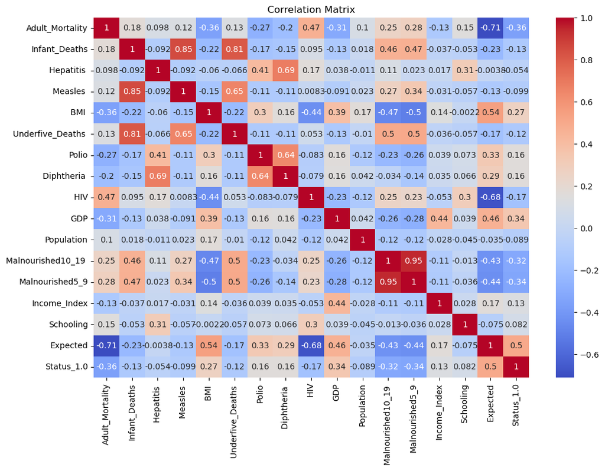

```python
# Correlation matrix
plt.figure(figsize=(12, 8))
sns.heatmap(df.corr(), annot=True, cmap='coolwarm')
plt.title('Correlation Matrix')
plt.show()
```

```python
# Step 4: Model Building
# Create a dictionary of models
models = {
    'Linear Regression': LinearRegression(),
    'Decision Tree': DecisionTreeRegressor(random_state=42),
    'Random Forest': RandomForestRegressor(random_state=42),
    'Gradient Boosting': GradientBoostingRegressor(random_state=42),
    'Support Vector Regression': SVR(),
    'Neural Network': MLPRegressor(random_state=42)
}
```

```python
# Standardize the data for models that require it
scaler = StandardScaler()
X_train_scaled = scaler.fit_transform(X_train)
X_test_scaled = scaler.transform(X_test)
```

```python
# Evaluate each model
results = {}
```

```python
for name, model in models.items():
    if name in ['Support Vector Regression', 'Neural Network']:
        model.fit(X_train_scaled, y_train)
        y_pred = model.predict(X_test_scaled)
    else:
        model.fit(X_train, y_train)
        y_pred = model.predict(X_test)

    mse = mean_squared_error(y_test, y_pred)
    mae = mean_absolute_error(y_test, y_pred)
    r2 = r2_score(y_test, y_pred)

    results[name] = {'MSE': mse, 'MAE': mae, 'R²': r2}
```

```python
# Display the results
results_df = pd.DataFrame(results).T
print(results_df)
```

```
                                   MSE        MAE         R²
Linear Regression            44.644576   4.661756   0.335810
Decision Tree                17.001200   3.068000   0.747068
Random Forest                 8.633976   2.129360   0.871550
Gradient Boosting             9.760354   2.215635   0.854792
Support Vector Regression    30.947244   4.199306   0.539589
Neural Network             2764.780261  51.744470 -40.132437
```

```python
# Step 5: Model Evaluation
##Based on the model performance, we can choose the best model and analyze feature importance.
# Assuming RandomForest performed the best
best_model = RandomForestRegressor(random_state=42)
best_model.fit(X_train, y_train)
```

```
RandomForestRegressor(random_state=42)
```

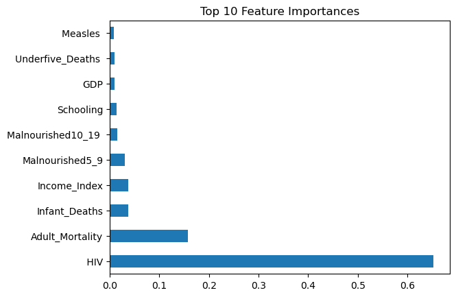

```python
# Feature importance
feature_importance = pd.Series(best_model.feature_importances_, index=X.columns)
feature_importance.nlargest(10).plot(kind='barh')
plt.title('Top 10 Feature Importances')
plt.show()
```

```python
## Step 6: Post-Model Analysis
##Summarize findings based on the model's performance and feature importance.
# Print top features
print(feature_importance.nlargest(10))

# Interpret the results and provide recommendations
```

```
 HIV                  0.652676
Adult_Mortality       0.157822
Infant_Deaths         0.037868
Income_Index          0.037551
Malnourished5_9       0.030199
Malnourished10_19     0.014981
Schooling             0.013732
GDP                   0.010381
Underfive_Deaths      0.009691
Measles               0.008314
dtype: float64
```

The 'HIV' variable has the highest importance, indicating that deaths due to HIV/AIDS have a significant negative impact on life expectancy. This highlights the critical need for effective HIV prevention, treatment, and education programs to reduce mortality rates associated with the disease. Adult Mortality:

The mortality rate for adults aged 15-60 is also a significant factor. Efforts to reduce adult mortality through better healthcare services, disease prevention, and health promotion activities can improve overall life expectancy. Infant Deaths:

The number of infant deaths per 1000 population is a crucial factor. Reducing infant mortality by improving maternal and child healthcare services can significantly enhance life expectancy. Income Index:

A higher income index (HDI in terms of national income per capita) is positively associated with life expectancy. Economic prosperity allows for better healthcare infrastructure, access to medical services, and improved living conditions, which contribute to longer life spans. Malnourished5_9 and Malnourished10_19:

Malnourishment in children aged 5-9 and 10-19 negatively affects life expectancy. Addressing malnutrition through better food security, nutrition programs, and public health interventions is essential for improving long-term health outcomes. Schooling:

Immunization rates for diseases like Measles, Polio, Diphtheria, and Hepatitis have some importance but are not among the top factors in this model. This may indicate that while vaccination is crucial, other healthcare services and socioeconomic factors play a more dominant role in determining life expectancy.